# Example application of the Cologne Protocol for the Early Neolithic of central Europe

M. Broich & R. Peters

11 March 2020

## Introduction

This manual presents an example application of the **Cologne Protocol** published in *Schmidt et al. (accepted)*. It is based upon the `.R` files which are in the `code\` directory. If you want to apply the Cologne Protocol on your own data, we recommend you to use these files, as it is possible to individually adjust certain variables at the beginning of the `00_LEC.R` file. However, the code chunks shown in this manual originate from the mentioned `.R` files.

The manual describes the first two parts of the Cologne Protocol, which are a GIS-analysis of site distribution and the identifying of so-called Core Areas. The aim of this document is neither to explain the further steps of the Cologne Protocol nor the theoretical background. For these points please refer to the associated publication including the supplementary information.

The goal of the script is to carry out all steps of the first part of the Cologne Protocol in R. These are (cf. *Schmidt et al. accepted, table S2*):

1. **Calculating “Largest Empty Circle”**
   1. Creating of Voronoi Polygons
   2. Extraction of Vertices
   3. Aggregation of Verticies
   4. Defining the Radius of the “Largest Empty Circle”
2. **Kriging**
   1. Preparation and Grid
   2. Semivariogram
   3. Inspect and Raster Output
3. **Optimally Describing Isolines**
   1. Creating Contour Lines (Isolines)
   2. Calculating the Area and Number of Sites per Ssoline
   3. Selecting the “Optimally Describing Isoline”
4. **Data export**

## Dependencies

To run the code of the script several packages are needed. These dependencies are stored in the `deps.yaml` file. It is possible to load them manually or to use `automagic::install_deps_file()` function. If the package `automagic` is not installed, it is possible to intsall it with `install.packages("automagic")`.  
Furthermore the script was developed under R version 3.6.3.

## Sample Data

For this examplary application, we use a distribution map of the Early Neolithic Linear Pottery Culture (LBK) in Central Europe. The map is based on *Preuss (1998, Karte 1)* and available from the CRC 806 database (https://crc806db.uni-koeln.de/start/).

The distribution map can be loaded into R via URL:

```r
# url_link of distribution map of Linear Pottery Culture
url_link <- "http://sfb806srv.uni-koeln.de/owsproxy.php?service=WFS&version=1.0.0&request=GetFeature&typeNames=geonode%3A_13_earlyneolithic_ce_sites_wgs84&outputFormat=csv"

# load date as a data.frame
sites <- read.csv(url(url_link))

# Conversion into SPDF
sites <- sp::SpatialPointsDataFrame(sp::SpatialPoints(
  cbind(sites$RECHTS, sites$HOCH)),
  sites,
  proj4string = CRS("+init=epsg:25832"))

# This is not a reprojection, but some function if the projection is not defined like this
sp::proj4string(sites) <- sp::CRS("+init=epsg:25832")
```

It is important to note, that cartesian coordinates (planar coord.) have to be used, because `rgeos::gDistance` will only accept planar coordinates. Especially Lat/Long-coordinates will cause a problem.

We can also plot the data:

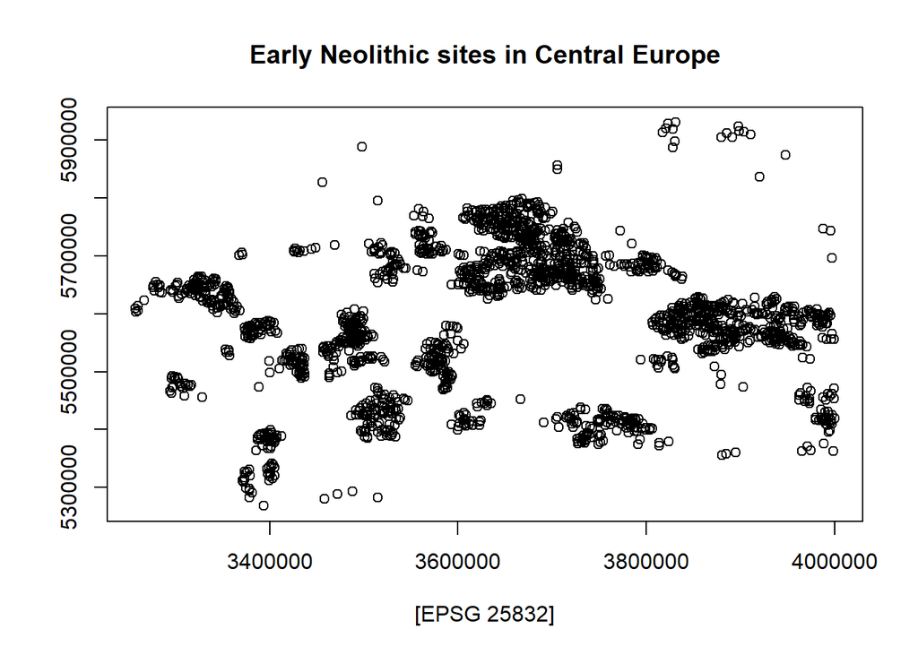

## Largest Empty Circle

The “Largest Empty Circle” (LEC) or more precicely the radius/diameter of a LEC is a meassure of site distance. Every LEC has it’s center at a vertix of a Voronoi polygon and exactly three sites are located on every periphery of a LEC. An illustartion can be found at *Zimmermann et al. (2004, Abb.5)*.  
To summarize, areas with larger site distances will be characterized by larger radii of LECs and, logically, areas with smaller site distances will be characterized by smaller radii of LECs.

### Creating of Voronoi polygons and Extraction of vertices

The first step is to calculate the voronoi polygons and to extract the vertices:

```r
# calculate voronoi polygons
voronoi_vertices <- deldir::deldir(sites@coords[, 1],
                                   sites@coords[, 2]) %$%
# extraction of vertices
  dirsgs
```

After the extraction of the vertices from the Voronoi polygons they have to be prepared to enable a transformation into a spdf (SpatialPointsDataFrame):

```r
# rearrange voronoi_vertices in preparation for transformation into an spdf
voronoi_vertices <- rbind(setNames(voronoi_vertices[,c(1:2, 5, 7, 9)],
                                   c("x", "y", "ind", "bp", "thirdv")),
                          setNames(voronoi_vertices[,c(3:4, 6, 8, 10)],
                                   c("x", "y", "ind", "bp", "thirdv")))
```

Finally, it is possible to transform the vertices into a spdf. Please note that the projection is explicitly assigned to the newly created `vertices_spdf`, since we have found that problems can otherwise arise:

```r
# transformation of voronoi_vertices into an spdf
vertices_spdf <- sp::SpatialPointsDataFrame(coords = voronoi_vertices[1:2],
                                            data = voronoi_vertices[, 3:5])

# Ignore warining! It's not a reprojection. But some functions need this step.
sp::proj4string(vertices_spdf) <- sp::CRS("+init=epsg:25832")
```

### Aggregation of verticies

During the step of extracting the vertices we did not care about that some of them were dublicates. In addition, some of the vertices are located at the border of the working area, the so-called border points. These points create artifical site distances and it must be decided in indiviual cases if the border points should be deleted or not. In the present example application we have to remove the dublicates but we will keep the border points.

```r
remove_border_points <- FALSE # Normally, this variable is defined in 00_LEC.R

# If Condition wether border points are removed or not
if(remove_border_points == TRUE){
# remove dublicates and border points
vertices_spdf <- sp::remove.duplicates(vertices_spdf) %>%
  {.[.[[2]] == FALSE, ]}
} else {
  # just remove dublicates
  vertices_spdf <- sp::remove.duplicates(vertices_spdf)
}
```

### Defining the radius of the “Largest Empty Circle”

## Kriging

### Inspect and Raster Output

## Optimally Describing Isolines

### Creating Contour Lines (Isolines)

### Calculating the Area and Number of Sites per Isoline

### Selecting the “Optimally Describing Isoline”

## Bibliography

Preuss, J. (ed.) **1998**. Das Neolithikum in Mitteleuropa: Kulturen, Wirtschaft, Umwelt vom 6. bis 3. Jahrtausend v. u. Z., Übersichten zum Stand der Forschung (Weissbach 1998).

Schmidt, I., Hilpert, J., Kretschmer, I., Peters, R., Broich, M., Schiesberg, S., Vogels, O., Wendt, K. P., Zimmermann, A., Maier, A., **accepted**. Approaching Prehistoric Demography: Proxies, Scales and Scope of the Cologne Protocol in European contexts. *Philosophical Transactions B*.

Zimmermann, A., Richter, J., Frank, T., Wendt, K.P., **2004**. Landschaftsarchäologie II. Überlegungen zu Prinzipien einer Landschaftsarchäologie. *Bericht der Römisch-Germanischen Kommission 85, 2004, 37-96*.